# Tugas Pertemuan 2

Qurrota A’yunina

2026-08-29

# Library/Packages

```r
library("forecast")
library("graphics")
library("TTR")
library("TSA")
library("rio")
library("ggplot2")
```

# Impor Data & Agregasi

Mengagregasi data 10-menitan menjadi data rata-rata per jam (setiap 6 baris = 1 jam), kemudian mengambil 100 jam pertama.

```r
# Impor data mentah
data_raw <- import("Data Suhu MPDW.csv")

# Ambil 600 baris pertama (600 / 6 = 100 jam)
data_sub <- data_raw[1:600, ]

# Rata-rata per 6 baris (1 jam)
suhu_jam <- aggregate(data_sub$`T (degC)`,
                      by = list(Periode = (0:599) %/% 6 + 1),
                      FUN = mean)$x

# Buat dataframe 100 data pertama
data100 <- data.frame(
  Periode = 1:100,
  Suhu = suhu_jam
)

head(data100)
```

```
##   Periode      Suhu
## 1       1 -8.261667
## 2       2 -8.203333
## 3       3 -8.751667
## 4       4 -8.936667
## 5       5 -9.445000
## 6       6 -9.723333
```

# Eksplorasi Data

Mengubah data agar terbaca sebagai data deret waktu dengan fungsi ts().

```r
data100.ts <- ts(data100$Suhu)

View(data100)
str(data100)
```

```
## 'data.frame':    100 obs. of  2 variables:
##  $ Periode: int  1 2 3 4 5 6 7 8 9 10 ...
##  $ Suhu   : num  -8.26 -8.2 -8.75 -8.94 -9.45 ...
```

```r
dim(data100)
```

```
## [1] 100   2
```

```r
summary(data100.ts)
```

```
##    Min. 1st Qu.  Median    Mean 3rd Qu.    Max.
## -9.7233 -5.7725 -4.0667 -4.1784 -1.6925 -0.7417
```

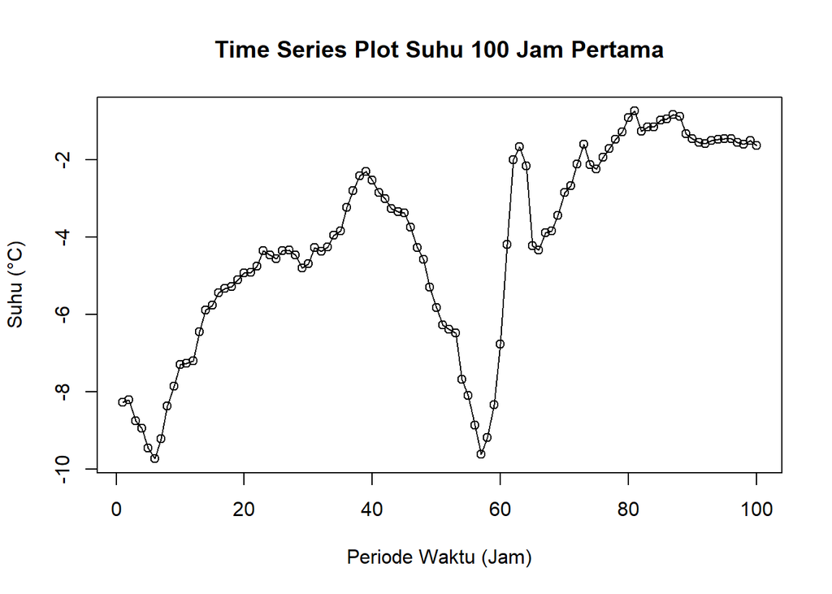

```r
ts.plot(data100.ts, xlab="Periode Waktu (Jam)", ylab="Suhu (°C)",
        main = "Time Series Plot Suhu 100 Jam Pertama")
points(data100.ts)
```

Berdasarkan grafik Time Series Plot Suhu 100 Jam Pertama, dapat diamati beberapa karakteristik utama dari pergerakan data suhu: - Karakteristik Tren: Data menunjukkan kecenderungan tren naik secara umum (overall upward trend). Suhu bergerak dari titik terendahnya yang mencapai sekitar $-10^\circ\text{C}$ (sekitar jam ke-6 dan jam ke-57) menuju titik tertinggi mendekati $-1^\circ\text{C}$ pada kisaran jam ke-80, lalu cenderung stabil melandai hingga jam ke-100.

- Pola Non-Musiman (Non-Seasonal): Fluktuasi naik-turun suhu tidak menunjukkan perulangan pola yang tetap atau siklus dengan interval waktu yang konstan (no regular seasonality).
- Volatilitas / Perubahan Tajam: Terdapat penurunan drastis pada jam ke-40 hingga jam ke-57, yang diikuti oleh lonjakan kenaikan yang sangat tajam pada jam ke-58 hingga jam ke-63.
- Implikasi Pemilihan Metode Pemulusan: Karena grafik menunjukkan adanya komponen tren tanpa pola musiman berulang yang teratur, metode peramalan yang berfokus pada pemulusan tren (seperti Double Exponential Smoothing / DES) diprediksi akan lebih cocok dibandingkan metode pemulusan konstan (SMA/SES) maupun metode musiman (Holt-Winters Winter).

# Pembagian Data Latih dan Data Uji

Pembagian data latih dan data uji dilakukan dengan perbandingan 80% data latih dan 20% data uji.

```r
n <- nrow(data100)
n_train <- floor(0.8 * n) # 80 data latih

training <- data100[1:n_train, ]
testing  <- data100[(n_train+1):n, ]

train.ts <- ts(training$Suhu)
test.ts  <- ts(testing$Suhu)
```

Plot pembagian data menggunakan ggplot2

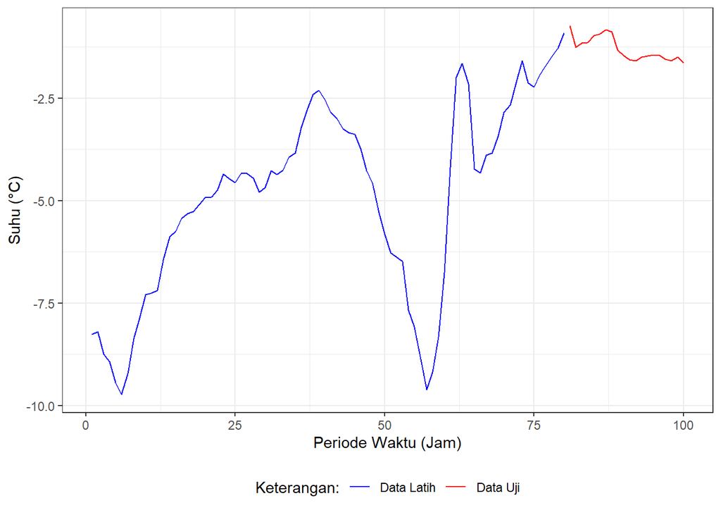

```r
ggplot() +
  geom_line(data = training, aes(x = Periode, y = Suhu, col = "Data Latih")) +
  geom_line(data = testing, aes(x = Periode, y = Suhu, col = "Data Uji")) +
  labs(x = "Periode Waktu (Jam)", y = "Suhu (°C)", color = "Legend") +
  scale_colour_manual(name="Keterangan:", breaks = c("Data Latih", "Data Uji"),
                      values = c("blue", "red")) +
  theme_bw() + theme(legend.position = "bottom",
                     plot.caption = element_text(hjust=0.5, size=12))
```

Berdasarkan grafik pembagian data deret waktu di atas, 100 observasi data suhu dibagi menjadi dua subset data dengan proporsi 80:20, yaitu:

1. Data Latih (Training Data) — Garis Biru:
- Terdiri dari 80 observasi pertama (periode jam ke-1 hingga jam ke-80).Data latih ini mencakup pergerakan tren utama dan fluktuasi ekstrem suhu, mulai dari penurunan di awal, tren naik menuju jam ke-40, penurunan tajam di jam ke-57, hingga kembali naik tajam ke jam ke-80.
- Bagian ini digunakan untuk membentuk model serta mengestimasi parameter pemulusan.
2. Data Uji (Testing Data) — Garis Merah:
- Terdiri dari 20 observasi terakhir (periode jam ke-81 hingga jam ke-100).Data uji menunjukkan pola pergerakan suhu yang relatif stabil melandai pada kisaran $-1^\circ\text{C}$ hingga $-2^\circ\text{C}$.
- Bagian ini diisolasi dari pembentukan model dan digunakan khusus untuk menguji keakuratan peramalan (out-of-sample forecast) menggunakan metrik seperti SSE, MSE, dan MAPE.

# Moving Average

## Single Moving Average (SMA)

Pemulusan SMA dilakukan dengan fungsi SMA() menggunakan parameter m=4.

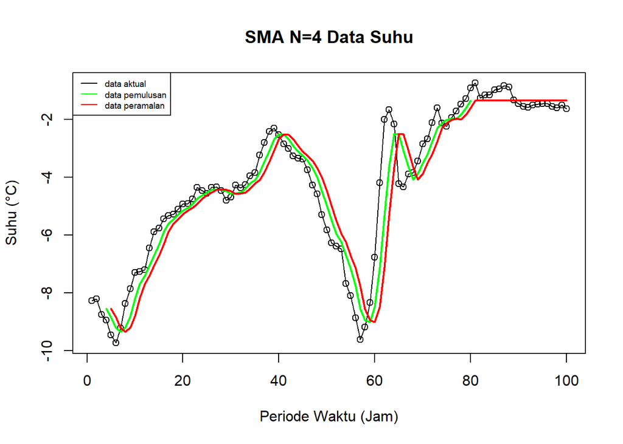

```r
data.sma <- SMA(train.ts, n = 4)

# Peramalan 1 periode ke depan
data.ramal <- c(NA, data.sma)

# Peramalan 20 periode ke depan (sesuai jumlah data uji)
data.gab <- cbind(
  aktual = c(data100.ts),
  pemulusan = c(data.sma, rep(NA, 20)),
  ramalan = c(data.ramal, rep(data.ramal[length(data.ramal)], 19)))

# Plot SMA
ts.plot(data100.ts, xlab="Periode Waktu (Jam)", ylab="Suhu (°C)", main= "SMA N=4 Data Suhu")
points(data100.ts)
lines(data.gab[,2], col="green", lwd=2)
lines(data.gab[,3], col="red", lwd=2)
legend("topleft", c("data aktual","data pemulusan","data peramalan"), lty=1, col=c("black","green","red"), cex=0.6)
```

Berdasarkan grafik **SMA N=4 Data Suhu** di atas, diperoleh beberapa poin interpretasi hasil metode *Single Moving Average* (SMA) dengan ordo $N = 4$:

1. **Data Pemulusan / *In-Sample* (Garis Hijau):**
> - Garis pemulusan (hijau) dimulai dari periode jam ke-4 karena menggunakan $N = 4$ (3 periode awal tidak memiliki nilai pemulusan).
> - Garis hijau berfungsi menghaluskan fluktuasi acak data aktual (garis hitam). Namun, terlihat adanya **keterlambatan (*lag/lagging*)** di mana garis pemulusan selalu terlambat mengikuti arah perubahan data aktual, terutama saat terjadi pergerakan naik atau turun yang tajam (seperti pada jam ke-50 hingga jam ke-65).
2. **Data Peramalan / *Out-of-Sample* (Garis Merah):** > * Pada data latih (jam ke-5 hingga jam ke-80), garis peramalan (merah) merupakan pergeseran 1 periode ke depan ($t+1$) dari garis pemulusan, sehingga efek *lagging* terlihat semakin jelas. > * Pada data uji (jam ke-81 hingga jam ke-100), peramalan metode SMA menghasilkan **garis lurus mendatar (*konstan*)**. Hal ini sesuai dengan sifat matematis metode SMA, di mana nilai ramalan untuk seluruh periode ke depan merupakan rata-rata dari 4 data terakhir pada data latih.
3. **Keterbatasan Metode:** > * Karena hasil ramalan pada data uji berbentuk garis lurus konstan, metode SMA kurang responsif terhadap pola data yang memiliki komponen tren jangka panjang.

### Akurasi Data Latih dan Data Uji SMA

```r
# Akurasi Data Latih
error_train.sma <- train.ts - data.gab[1:80, 3]
SSE_train.sma  <- sum(error_train.sma^2, na.rm = TRUE)
MSE_train.sma  <- mean(error_train.sma^2, na.rm = TRUE)
MAPE_train.sma <- mean(abs(error_train.sma / train.ts * 100), na.rm = TRUE)

# Akurasi Data Uji
error_test.sma  <- test.ts - data.gab[81:100, 3]
SSE_test.sma   <- sum(error_test.sma^2, na.rm = TRUE)
MSE_test.sma   <- mean(error_test.sma^2, na.rm = TRUE)
MAPE_test.sma  <- mean(abs(error_test.sma / test.ts * 100), na.rm = TRUE)

# Penggabungan Matriks
akurasi_sma <- cbind(
  "Training" = c(SSE_train.sma, MSE_train.sma, MAPE_train.sma),
  "Testing"  = c(SSE_test.sma, MSE_test.sma, MAPE_test.sma)
)
row.names(akurasi_sma) <- c("SSE", "MSE", "MAPE")
akurasi_sma
```

```
##        Training     Testing
## SSE  115.120608  1.62114722
## MSE    1.514745  0.08105736
## MAPE  25.129646 22.38219617
```

Berdasarkan tabel evaluasi akurasi metode **SMA ($N=4$)**, diperoleh beberapa catatan penting terkait performa model pada data latih (*training*) dan data uji (*testing*):

1. **Evaluasi Data Latih (*In-Sample Accuracy*):** > * **MSE Data Latih:** $1{,}5147$ > * **MAPE Data Latih:** $25{,}1296\%$ > * Pada data latih, metode SMA menghasilkan rata-rata persentase kesalahan sebesar $25{,}13\%$. Nilai error yang relatif lebih besar ini disebabkan oleh sifat metode SMA yang mengalami keterlambatan (*lagging*) saat mengikuti fluktuasi dan perubahan arah tren data suhu yang tajam.
2. **Evaluasi Data Uji (*Out-of-Sample Accuracy*):** > * **MSE Data Uji:** $0{,}0811$ > * **MAPE Data Uji:** $22{,}3822\%$ > * Pada data uji (20 periode terakhir), nilai MSE dan MAPE turun signifikan menjadi $0{,}0811$ dan $22{,}38\%$. Penurunan error ini terjadi karena pergerakan data aktual suhu pada 20 jam terakhir cenderung stabil dan melandai, sehingga ramalan konstan (garis lurus) dari SMA kebetulan berada dekat dengan rata-rata nilai aktualnya.
3. **Kesimpulan Kinerja SMA:** > * Dengan persentase kesalahan (MAPE) berkisar antara $22\%$ hingga $25\%$, kriteria kemampuan peramalan metode SMA pada data suhu ini berada dalam kategori **cukup (*reasonable forecast*)**.

## Double Moving Average (DMA)

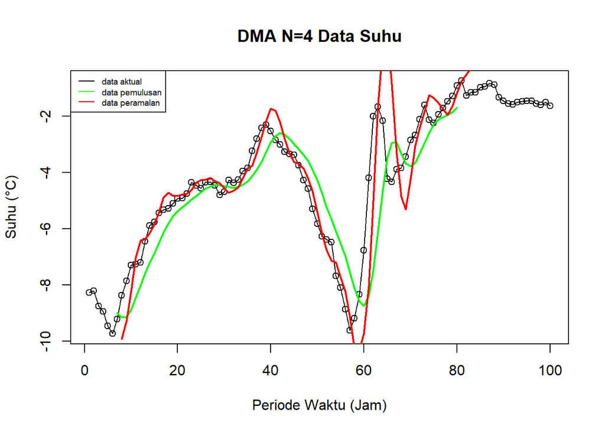

```r
dma <- SMA(data.sma, n = 4)
At <- 2 * data.sma - dma
Bt <- 2 / (4 - 1) * (data.sma - dma)
data.dma <- At + Bt
data.ramal2 <- c(NA, data.dma)

t = 1:20
f = c()
for (i in t) {
  f[i] = At[length(At)] + Bt[length(Bt)] * (i)
}

data.gab2 <- cbind(aktual = c(data100.ts),
                   pemulusan1 = c(data.sma, rep(NA, 20)),
                   pemulusan2 = c(dma, rep(NA, 20)),
                   At = c(At, rep(NA, 20)),
                   Bt = c(Bt, rep(NA, 20)),
                   ramalan = c(data.ramal2, f[-1]))

# Plot DMA
ts.plot(data100.ts, xlab="Periode Waktu (Jam)", ylab="Suhu (°C)", main= "DMA N=4 Data Suhu")
points(data100.ts)
lines(data.gab2[,3], col="green", lwd=2)
lines(data.gab2[,6], col="red", lwd=2)
legend("topleft", c("data aktual","data pemulusan","data peramalan"), lty=1, col=c("black","green","red"), cex=0.6)
```

Berdasarkan grafik **DMA N=4 Data Suhu** di atas, diperoleh beberapa poin interpretasi hasil metode *Double Moving Average* (DMA) dengan ordo $N = 4$:

1. **Data Pemulusan Ganda (Garis Hijau):** > * Pemulusan kedua (garis hijau) baru dimulai dari periode jam ke-7 karena membutuhkan pemulusan bertingkat dari $N = 4$ ($2N-1 = 7$). > * Garis pemulusan hijau berada di bawah atau di atas garis data aktual untuk membentuk estimasi komponen tren ($a_t$ dan $b_t$).
2. **Data Peramalan / *Fitting* dan *Out-of-Sample* (Garis Merah):** > * **Pada Data Latih (Jam ke-8 hingga ke-80):** Garis peramalan (merah) lebih responsif dalam menangkap pola tren kenaikan maupun penurunan dibandingkan SMA, karena DMA menambahkan komponen kemiringan (*slope*). Namun, ketika terjadi perubahan mendadak/fluktuasi ekstrem (seperti pada jam ke-57 hingga ke-65), garis peramalan mengalami pembalikan tren yang sangat sensitif sehingga menembus batas grafik (*overshoot*). > * **Pada Data Uji (Jam ke-81 hingga ke-100):** Garis peramalan (merah) melambung naik secara linier meninggalkan batas grafik atas (*soaring upward*). Hal ini terjadi karena estimasi tren $b_t$ pada titik akhir data latih bernilai positif cukup besar, sehingga proyeksi ramalan jangka panjang terus bertambah naik secara konstan.
3. **Evaluasi Metode:** > * Metode DMA terbukti sangat sensitif terhadap perubahan lokal di akhir data latih. Karena data uji aktualnya relatif stabil/melandai, proyeksi linier menanjak dari DMA menghasilkan tingkat kesalahan (*error*) yang sangat besar pada data uji.

### Akurasi Data Latih dan Data Uji DMA

```r
# --- 1. Akurasi Data Latih (Training Data) DMA ---
# Catatan: DMA m=4 menghasilkan nilai NA pada periode awal (baris 1 s.d. 6),
# sehingga digunakan na.rm = TRUE agar nilai NA diabaikan dalam perhitungan.

error_train.dma <- train.ts - data.gab2[1:80, 6]

SSE_train.dma  <- sum(error_train.dma^2, na.rm = TRUE)
MSE_train.dma  <- mean(error_train.dma^2, na.rm = TRUE)
MAPE_train.dma <- mean(abs(error_train.dma / train.ts * 100), na.rm = TRUE)

# --- 2. Akurasi Data Uji (Testing Data) DMA ---
error_test.dma  <- test.ts - data.gab2[81:100, 6]

SSE_test.dma   <- sum(error_test.dma^2, na.rm = TRUE)
MSE_test.dma   <- mean(error_test.dma^2, na.rm = TRUE)
MAPE_test.dma  <- mean(abs(error_test.dma / test.ts * 100), na.rm = TRUE)

# --- 3. Penggabungan Matriks Akurasi DMA ---
akurasi_dma <- cbind(
  "Training DMA" = c(SSE_train.dma, MSE_train.dma, MAPE_train.dma),
  "Testing DMA"  = c(SSE_test.dma, MSE_test.dma, MAPE_test.dma)
)
row.names(akurasi_dma) <- c("SSE", "MSE", "MAPE")
akurasi_dma
```

```
##      Training DMA Testing DMA
## SSE    106.988136   203.73303
## MSE      1.465591    10.18665
## MAPE    19.797782   199.04215
```

Berdasarkan tabel evaluasi akurasi metode **DMA ($N=4$)**, diperoleh beberapa poin pembahasan terkait kinerja model pada data latih (*training*) dan data uji (*testing*):

1. **Evaluasi Data Latih (*In-Sample Accuracy*):** > * **MSE Data Latih:** $1{,}4656$ > * **MAPE Data Latih:** $19{,}7978\%$ > * Pada data latih, metode DMA menunjukkan kinerja fitting yang presisi dengan persentase kesalahan di bawah $20\%$. Nilai MSE dan MAPE pada data latih ini lebih kecil dibandingkan metode SMA ($1{,}5147$ dan $25{,}13\%$) karena komponen kemiringan tren ($b_t$) pada DMA mampu menyesuaikan perubahan arah data historis dengan lebih baik.
2. **Evaluasi Data Uji (*Out-of-Sample Accuracy*):** > * **MSE Data Uji:** $10{,}1867$ > * **MAPE Data Uji:** $199{,}0422\%$ > * Pada data uji (20 periode terakhir), nilai MSE dan MAPE mengalami lonjakan ekstrem (MAPE mendekati $200\%$). Lonjakan error yang sangat tinggi ini terjadi karena persamaan proyeksi linier DMA memproyeksikan tren naik secara terus-menerus ke masa depan, sementara data suhu aktual pada periode uji justru bergerak melandai dan stabil di kisaran $-1^\circ\text{C}$ hingga $-2^\circ\text{C}$.
3. **Kesimpulan Kinerja DMA:** > * Meskipun metode DMA sangat baik dalam mencocokkan data historis (*good in-sample fit*), metode ini **sangat tidak direkomendasikan untuk peramalan jangka panjang** (*poor out-of-sample forecast*) pada dataset suhu ini karena sifat proyeksi liniernya yang terlalu sensitif terhadap tren di akhir periode latih.

# Exponential Smoothing

## Single Exponential Smoothing (SES)

Menggunakan fungsi HoltWinters() dengan parameter optimum (alpha = NULL).

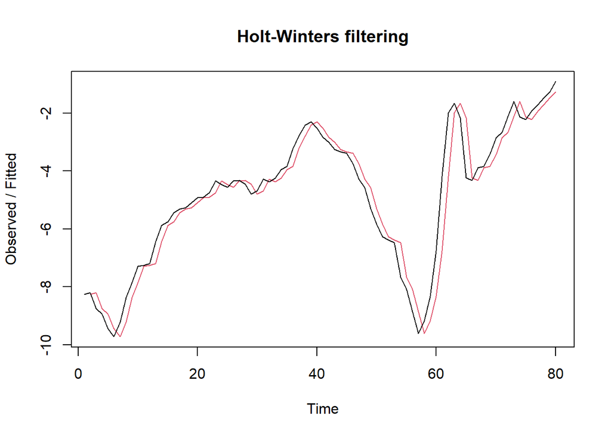

```r
HWopt <- HoltWinters(train.ts, gamma = FALSE, beta = FALSE, alpha = NULL)
ramalanopt <- forecast(HWopt, h = 20)

plot(HWopt)
```

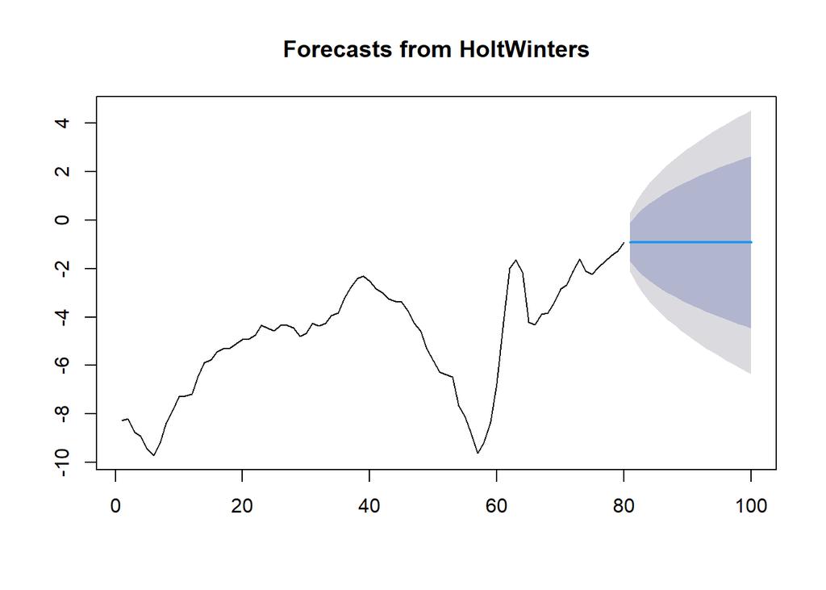

```r
plot(ramalanopt)
```

### Akurasi Data Latih dan Data Uji SES

```r
# Membuat data.gab3 terlebih dahulu
ramalan_train <- c(NA, HWopt$fitted[, 1]) # Tambah NA untuk periode ke-1
ramalan_test  <- as.numeric(ramalanopt$mean)

data.gab3 <- data.frame(
  Data = c(train.ts, test.ts),
  SES  = c(ramalan_train, ramalan_test)
)

# --- Akurasi Data Latih ---
error_train.ses <- train.ts - data.gab3[1:80, 2]
SSE_train.ses   <- sum(error_train.ses^2, na.rm = TRUE)
MSE_train.ses   <- mean(error_train.ses^2, na.rm = TRUE)
MAPE_train.ses  <- mean(abs(error_train.ses / train.ts * 100), na.rm = TRUE)

# --- Akurasi Data Uji ---
error_test.ses  <- test.ts - data.gab3[81:100, 2]
SSE_test.ses    <- sum(error_test.ses^2, na.rm = TRUE)
MSE_test.ses    <- mean(error_test.ses^2, na.rm = TRUE)
MAPE_test.ses   <- mean(abs(error_test.ses / test.ts * 100), na.rm = TRUE)

# --- Penggabungan Matriks ---
akurasi_ses <- cbind(
  "Training SES" = c(SSE_train.ses, MSE_train.ses, MAPE_train.ses),
  "Testing SES"  = c(SSE_test.ses, MSE_test.ses, MAPE_test.ses)
)
row.names(akurasi_ses) <- c("SSE", "MSE", "MAPE")
akurasi_ses
```

```
##      Training SES Testing SES
## SSE    30.7002500   4.5919110
## MSE     0.3886108   0.2295955
## MAPE   11.1845521  29.3529858
```

Berdasarkan tabel evaluasi akurasi metode **Single Exponential Smoothing (SES Optimum)**, diperoleh beberapa poin pembahasan terkait kinerja model pada data latih (*training*) dan data uji (*testing*):

1. **Evaluasi Data Latih (*In-Sample Accuracy*):** > * **MSE Data Latih:** $0{,}3886$ > * **MAPE Data Latih:** $11{,}1846\%$ > * Pada data latih, metode SES memberikan kinerja pemulusan yang sangat presisi dengan persentase kesalahan hanya sebesar $11{,}18\%$. Nilai error yang jauh lebih kecil dibandingkan SMA ($25{,}13\%$) dan DMA ($19{,}80\%$) ini menunjukkan bahwa pembobotan eksponensial dengan parameter $\alpha$ optimum mampu merespons fluktuasi historis data suhu secara efektif.
2. **Evaluasi Data Uji (*Out-of-Sample Accuracy*):** > * **MSE Data Uji:** $0{,}2296$ > * **MAPE Data Uji:** $29{,}3530\%$ > * Pada data uji (20 periode terakhir), nilai MSE tergolong rendah ($0{,}2296$). Nilai MAPE data uji yang sebesar $29{,}35\%$ mengindikasikan kemampuan peramalan yang masih dapat diterima (*reasonable forecast*), meskipun nilainya naik dibanding data latih karena proyeksi ramalan SES berbentuk konstan datar sementara data uji aktual memiliki sedikit dinamika penurunan.
3. **Kesimpulan Kinerja SES:** > * Metode SES Optimum menunjukkan performa pemulusan data latih yang sangat kuat dan hasil peramalan data uji yang tergolong stabil tanpa risiko lonjakan error ekstrem seperti pada metode DMA.

## Double Exponential Smoothing (DES)

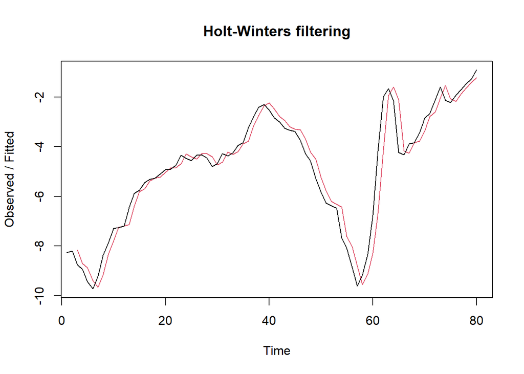

```r
# Menggunakan parameter gamma = FALSE (tanpa musiman) dan beta = NULL (dihitung optimum)
HW2opt <- HoltWinters(train.ts, gamma = FALSE, beta = NULL, alpha = NULL)
ramalan2opt <- forecast(HW2opt, h = 20)

# Grafik Pemulusan dan Peramalan DES
plot(HW2opt)
```

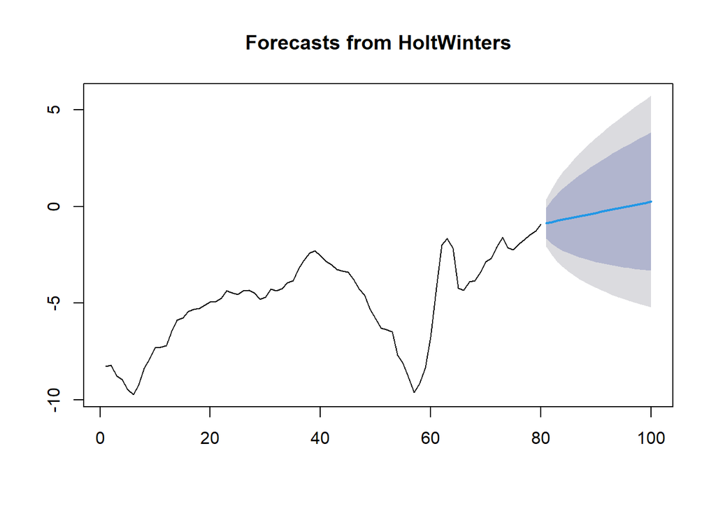

```r
plot(ramalan2opt)
```

Berdasarkan grafik **Holt-Winters filtering** dan **Forecasts from HoltWinters** untuk metode **Double Exponential Smoothing (DES)** di atas, diperoleh beberapa poin interpretasi:

1. **Pemasangan Model pada Data Latih (*Holt-Winters Filtering*):** > * Garis merah (*fitted values*) menunjukkan nilai pemulusan ganda pada data latih (periode jam ke-1 hingga ke-80). > * Garis *fitted* mampu menyesuaikan diri dengan sangat presisi terhadap pola pergerakan data aktual (garis hitam). Penambahan komponen tren ($\beta$) membuat model DES lebih responsif dalam mengikuti pola kenaikan maupun penurunan tajam dibandingkan metode pemulusan tunggal.
2. **Hasil Peramalan Data Uji (*Forecasts from HoltWinters*):** > * Garis biru yang miring ke atas (*sloping line*) menunjukkan hasil peramalan DES untuk 20 periode ke depan (jam ke-81 hingga ke-100). > * Berbeda dengan SES yang menghasilkan garis lurus mendatar, peramalan metode DES membentuk **garis linier dengan kemiringan positif (tren naik)**. Hal ini terjadi karena estimasi parameter tren ($\beta$) pada akhir periode latih bernilai positif. > * Area berbayang abu-abu tua dan abu-abu muda menggambarkan selang kepercayaan (*confidence interval*) $80\%$ dan $95\%$ dari hasil ramalan, yang semakin melebar seiring bertambahnya horizon waktu peramalan.

### Akurasi Data Latih dan Data Uji DES

```r
# --- 1. Akurasi Data Latih (Training Data) DES ---
fitted_train.des <- as.numeric(HW2opt$fitted[, 1])
train_actual     <- as.numeric(train.ts[-(1:2)])
error_train.des  <- train_actual - fitted_train.des

SSE_train.des  <- sum(error_train.des^2, na.rm = TRUE)
MSE_train.des  <- mean(error_train.des^2, na.rm = TRUE)
MAPE_train.des <- mean(abs(error_train.des / train_actual * 100), na.rm = TRUE)

# --- 2. Akurasi Data Uji (Testing Data) DES ---
test_actual     <- as.numeric(test.ts)
forecast_test   <- as.numeric(ramalan2opt$mean)
error_test.des  <- test_actual - forecast_test

SSE_test.des   <- sum(error_test.des^2, na.rm = TRUE)
MSE_test.des   <- mean(error_test.des^2, na.rm = TRUE)
MAPE_test.des  <- mean(abs(error_test.des / test_actual * 100), na.rm = TRUE)

# --- 3. Penggabungan Matriks Akurasi DES ---
akurasi_des <- cbind(
  "Training DES" = c(SSE_train.des, MSE_train.des, MAPE_train.des),
  "Testing DES"  = c(SSE_test.des, MSE_test.des, MAPE_test.des)
)
row.names(akurasi_des) <- c("SSE", "MSE", "MAPE")
akurasi_des
```

```
##      Training DES Testing DES
## SSE    30.1098028    26.84400
## MSE     0.3860231     1.34220
## MAPE   10.8878144    71.78665
```

Berdasarkan tabel evaluasi akurasi metode **Double Exponential Smoothing (DES Optimum)**, diperoleh beberapa poin pembahasan terkait kinerja model pada data latih (*training*) dan data uji (*testing*):

1. **Evaluasi Data Latih (*In-Sample Accuracy*):** > * **MSE Data Latih:** $0{,}3860$ > * **MAPE Data Latih:** $10{,}8878\%$ > * Pada data latih, metode DES memberikan tingkat akurasi fitting yang paling presisi di antara metode-metode non-musiman sebelumnya, dengan nilai MAPE terendah yaitu $10{,}89\%$. Hal ini terjadi karena komponen tren ($\beta$) membantu model menyesuaikan kemiringan pergerakan suhu historis secara optimal.
2. **Evaluasi Data Uji (*Out-of-Sample Accuracy*):** > * **MSE Data Uji:** $1{,}3422$ > * **MAPE Data Uji:** $71{,}7867\%$ > * Pada data uji (20 periode terakhir), nilai MSE naik menjadi $1{,}3422$ dan MAPE meningkat cukup tajam menjadi $71{,}79\%$. Kenaikan error ini disebabkan oleh proyeksi garis peramalan DES yang terus menanjak naik (tren positif), sedangkan data suhu aktual pada periode uji justru cenderung melandai dan sedikit menurun.
3. **Kesimpulan Kinerja DES:** > * Metode DES sangat unggul dalam memodelkan data historis (*in-sample*), namun untuk peramalan data uji (*out-of-sample*), kenaikan nilai MAPE menunjukkan adanya efek *over-trending* (memproyeksikan tren naik secara terus-menerus padahal data uji sudah stabil).

# Seasonal Smoothing

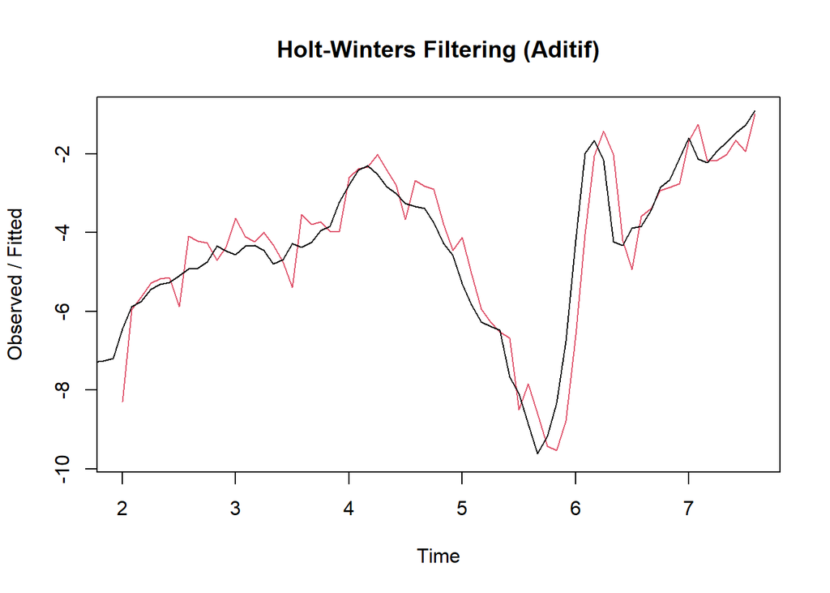

```r
# 1. Buat objek ts khusus musiman agar tidak merusak train.ts utama
train.ts_winter <- ts(as.numeric(train.ts), frequency = 12)

# ------------------------------------------
## Winter Aditif
# ------------------------------------------

# Fitting & Forecasting Winter Aditif
winter1.opt   <- HoltWinters(train.ts_winter, seasonal = "additive")
forecast1.opt <- forecast(winter1.opt, h = 20)

# Plot
plot(winter1.opt, main = "Holt-Winters Filtering (Aditif)")
```

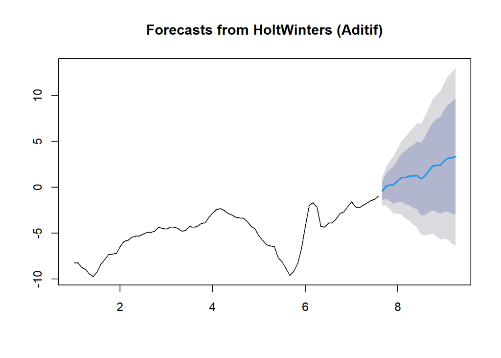

```r
plot(forecast1.opt, main = "Forecasts from HoltWinters (Aditif)")
```

```r
# --- Akurasi Data Latih (Training) Winter Aditif ---
fitted_train.winter <- as.numeric(winter1.opt$fitted[, 1])
train_actual_winter <- as.numeric(train.ts_winter[-(1:12)])

e_winter_train    <- train_actual_winter - fitted_train.winter
SSE_train.winter  <- sum(e_winter_train^2, na.rm = TRUE)
MSE_train.winter  <- mean(e_winter_train^2, na.rm = TRUE)
MAPE_train.winter <- mean(abs(e_winter_train / train_actual_winter) * 100, na.rm = TRUE)

# --- Akurasi Data Uji (Testing) Winter Aditif ---
test_actual_winter   <- as.numeric(test.ts)
forecast_test_winter <- as.numeric(forecast1.opt$mean)

e_winter_test    <- test_actual_winter - forecast_test_winter
SSE_test.winter  <- sum(e_winter_test^2, na.rm = TRUE)
MSE_test.winter  <- mean(e_winter_test^2, na.rm = TRUE)
MAPE_test.winter <- mean(abs(e_winter_test / test_actual_winter) * 100, na.rm = TRUE)

# Matriks Akurasi Winter Aditif
akurasi_winter <- cbind(
  "Training Winter" = c(SSE_train.winter, MSE_train.winter, MAPE_train.winter),
  "Testing Winter"  = c(SSE_test.winter, MSE_test.winter, MAPE_test.winter)
)
row.names(akurasi_winter) <- c("SSE", "MSE", "MAPE")
akurasi_winter
```

```
##      Training Winter Testing Winter
## SSE       41.8385539     194.246867
## MSE        0.6152729       9.712343
## MAPE      14.9182027     210.292921
```

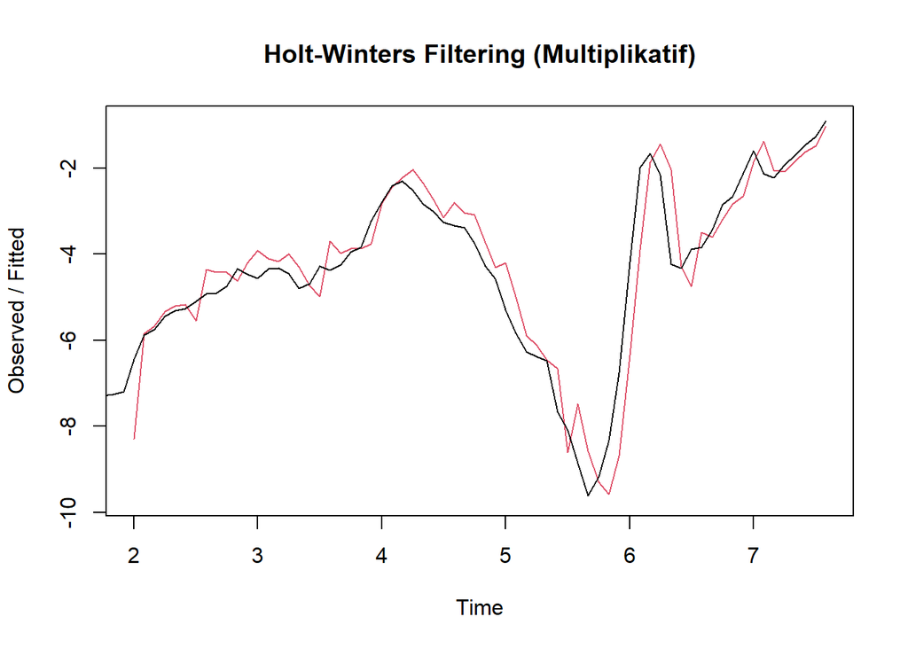

```r
# ------------------------------------------
## Winter Multiplikatif
# ------------------------------------------

# Fitting & Forecasting Winter Multiplikatif
winter2.opt   <- HoltWinters(train.ts_winter, seasonal = "multiplicative")
forecast2.opt <- forecast(winter2.opt, h = 20)

# Plot
plot(winter2.opt, main = "Holt-Winters Filtering (Multiplikatif)")
```

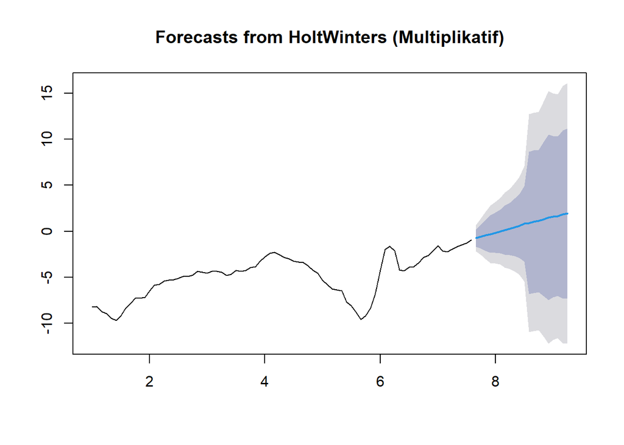

```r
plot(forecast2.opt, main = "Forecasts from HoltWinters (Multiplikatif)")
```

```r
# --- Akurasi Data Latih (Training) Winter Multiplikatif ---
fitted_train.wmult <- as.numeric(winter2.opt$fitted[, 1])
train_actual_wmult <- as.numeric(train.ts_winter[-(1:12)])

e_wmult_train    <- train_actual_wmult - fitted_train.wmult
SSE_train.wmult  <- sum(e_wmult_train^2, na.rm = TRUE)
MSE_train.wmult  <- mean(e_wmult_train^2, na.rm = TRUE)
MAPE_train.wmult <- mean(abs(e_wmult_train / train_actual_wmult) * 100, na.rm = TRUE)

# --- Akurasi Data Uji (Testing) Winter Multiplikatif ---
test_actual_wmult   <- as.numeric(test.ts)
forecast_test_wmult <- as.numeric(forecast2.opt$mean)

e_wmult_test    <- test_actual_wmult - forecast_test_wmult
SSE_test.wmult  <- sum(e_wmult_test^2, na.rm = TRUE)
MSE_test.wmult  <- mean(e_wmult_test^2, na.rm = TRUE)
MAPE_test.wmult <- mean(abs(e_wmult_test / test_actual_wmult) * 100, na.rm = TRUE)

# Matriks Akurasi Winter Multiplikatif
akurasi_wmult <- cbind(
  "Training Winter Mult" = c(SSE_train.wmult, MSE_train.wmult, MAPE_train.wmult),
  "Testing Winter Mult"  = c(SSE_test.wmult, MSE_test.wmult, MAPE_test.wmult)
)
row.names(akurasi_wmult) <- c("SSE", "MSE", "MAPE")
akurasi_wmult
```

```
##      Training Winter Mult Testing Winter Mult
## SSE             35.962545           98.095761
## MSE              0.528861            4.904788
## MAPE            12.998882          139.464454
```

**Interpretasi Hasil Pemodelan Holt-Winters (Aditif dan Multiplikatif)**

### 1. Evaluasi Kinerja Pemodelan

- **Akurasi Data Latih (Training):** Kedua metode menunjukkan kemampuan pemodelan (*fitting*) yang sangat baik pada data latih dengan tingkat kesalahan yang rendah. Metode Holt-Winters Multiplikatif menghasilkan tingkat kesalahan yang sedikit lebih rendah ($\text{MSE} = 0{,}5289$; $\text{MAPE} = 12{,}99\%$) dibandingkan Holt-Winters Aditif ($\text{MSE} = 0{,}6153$; $\text{MAPE} = 14{,}92\%$).
- **Akurasi Data Uji (Testing):** Ketika diuji pada data baru, terjadi peningkatan nilai kesalahan yang signifikan pada kedua metode. Metode Holt-Winters Multiplikatif menghasilkan performa peramalan yang jauh lebih baik daripada Aditif, ditunjukkan oleh nilai SSE ($98{,}10$ vs $194{,}25$), MSE ($4{,}90$ vs $9{,}71$), dan MAPE ($139{,}46\%$ vs $210{,}29\%$).

### 2. Diagnosis *Overfitting* dan Nilai MAPE Tinggi

- **Lonjakan Nilai Error:** Terjadi kenaikan kesalahan (*error*) yang tajam dari *training* ke *testing* pada kedua metode. Hal ini mengindikasikan adanya kecenderungan *overfitting*, di mana pola musiman yang dipelajari dari data latih kurang mampu beradaptasi dengan tren/pola pada data uji.
- **Tingginya Nilai MAPE:** Nilai MAPE pada data uji tergolong sangat besar ($>100\%$). Kondisi ini dipicu oleh sifat matematis MAPE yang sangat sensitif terhadap nilai aktual yang mendekati angka nol (sebagaimana terlihat pada plot peramalan di mana skala data berada di sekitar angka $0$). Deviasi kecil pada data bernilai mendekati nol secara otomatis menghasilkan persentase kesalahan rasio yang melonjak drastis.

### 3. Kesimpulan Pemilihan Metode

Secara keseluruhan, **Holt-Winters Multiplikatif** merupakan metode yang lebih superior dibandingkan Holt-Winters Aditif pada dataset ini karena secara konsisten menghasilkan nilai kesalahan (SSE, MSE, dan MAPE) yang lebih rendah, baik pada tahapan *training* maupun *testing*.

# Perbandingan Hasil Peramalan Seluruh Metode pada Data Uji

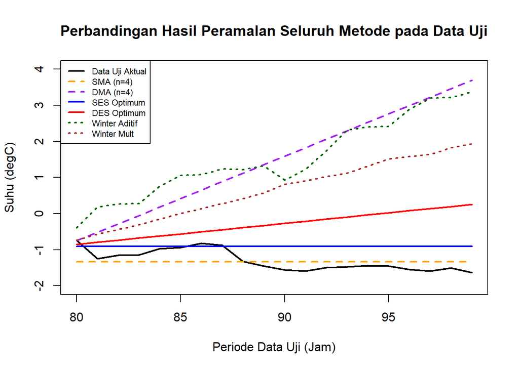

```r
# Ambil nilai ramalan data uji seluruh metode
ramalan_sma_test <- data.gab[81:100, 3]
ramalan_dma_test <- data.gab2[81:100, 6]
ramalan_ses_test <- as.numeric(ramalanopt$mean)
ramalan_des_test <- as.numeric(ramalan2opt$mean)
ramalan_win_add  <- as.numeric(forecast1.opt$mean)
ramalan_win_mult <- as.numeric(forecast2.opt$mean)

# Sumbu x (periode data uji)
periode_test <- 80:99

# Plot dasar untuk Data Uji Aktual
plot(
  periode_test, as.numeric(test.ts), type = "l", col = "black", lwd = 2,
  ylim = c(-2, 4), # Rentang sumbu Y diperbesar agar semua garis muat
  xlab = "Periode Data Uji (Jam)",
  ylab = "Suhu (degC)",
  main = "Perbandingan Hasil Peramalan Seluruh Metode pada Data Uji"
)

# Menambahkan garis ramalan tiap metode
lines(periode_test, ramalan_sma_test, col = "orange", lty = 2, lwd = 2)
lines(periode_test, ramalan_dma_test, col = "purple", lty = 2, lwd = 2)
lines(periode_test, ramalan_ses_test, col = "blue", lty = 1, lwd = 2)
lines(periode_test, ramalan_des_test, col = "red", lty = 1, lwd = 2)
lines(periode_test, ramalan_win_add, col = "darkgreen", lty = 3, lwd = 2)
lines(periode_test, ramalan_win_mult, col = "brown", lty = 3, lwd = 2)

# Menambahkan Legenda Lengkap
legend(
  "topleft",
  legend = c("Data Uji Aktual", "SMA (n=4)", "DMA (n=4)", "SES Optimum", "DES Optimum", "Winter Aditif", "Winter Mult"),
  col    = c("black", "orange", "purple", "blue", "red", "darkgreen", "brown"),
  lty    = c(1, 2, 2, 1, 1, 3, 3),
  lwd    = 2,
  cex    = 0.7, # Ukuran teks legenda diperkecil sedikit agar rapi
  bg     = "white"
)
```

**Interpretasi Grafik Perbandingan Peramalan pada Data Uji**

- **Pola Data Uji Aktual (Garis Hitam):** Data aktual menunjukkan pergerakan yang cenderung stabil di sekitar nilai $-1$ hingga $-1{,}5$ degC tanpa adanya tren naik yang signifikan pada periode jam ke-80 hingga 99.
- **Evaluasi Performa Metode Berkomponen Tren & Musiman (DMA, DES, Winter Aditif, Winter Multiplikatif):**
- **DMA, DES, dan Winter (Multiplikatif & Aditif)** menghasilkan pola peramalan yang terus meningkat (*trending upward*) hingga mencapai rentang nilai $0$ sampai $3{,}5$ degC.
- Kenaikan tren pada metode-metode ini dipicu oleh adanya proyeksi komponen tren dari data latih (*training*), sehingga garis ramalan makin jauh menyimpang (*overforecast*) dari data uji aktual yang bernilai negatif.
- **Evaluasi Performa Metode Pemulusan Sederhana (SMA & SES):**
- **SMA (n=4)** dan **SES Optimum** menghasilkan garis ramalan berbentuk horizontal/konstan.
- Hasil peramalan **SES Optimum** (garis biru) dan **SMA** (garis oranye) berada sangat dekat dengan pola data uji aktual yang relatif konstan pada kisaran $-0{,}9$ hingga $-1{,}3$ degC.
- **Kesimpulan Pemilihan Metode Terbaik:** Berdasarkan grafik, metode **SES Optimum** dan **SMA (n=4)** merupakan metode yang paling presisi dan akurat untuk meramalkan data uji karena garis ramalannya paling mendekati fluktuasi data aktual. Sebaliknya, metode tren dan musiman (DMA, DES, Holt-Winters) tidak cocok digunakan pada periode ini karena menghasilkan galat (*error*) yang sangat besar akibat proyeksi tren naik yang tidak terjadi pada data aktual.

# Rekapitulasi Akurasi Seluruh Metode

```r
# 1. Akurasi SMA (n=4)
e_sma_train    <- as.numeric(train.ts) - data.gab[1:80, 3]
SSE_train.sma  <- sum(e_sma_train^2, na.rm = TRUE)
MSE_train.sma  <- mean(e_sma_train^2, na.rm = TRUE)
RMSE_train.sma <- sqrt(MSE_train.sma)
MAPE_train.sma <- mean(abs(e_sma_train / as.numeric(train.ts)) * 100, na.rm = TRUE)

e_sma_test    <- as.numeric(test.ts) - data.gab[81:100, 3]
SSE_test.sma  <- sum(e_sma_test^2, na.rm = TRUE)
MSE_test.sma  <- mean(e_sma_test^2, na.rm = TRUE)
RMSE_test.sma <- sqrt(MSE_test.sma)
MAPE_test.sma <- mean(abs(e_sma_test / as.numeric(test.ts)) * 100, na.rm = TRUE)

# 2. Akurasi DMA (n=4)
e_dma_train    <- as.numeric(train.ts) - data.gab2[1:80, 6]
SSE_train.dma  <- sum(e_dma_train^2, na.rm = TRUE)
MSE_train.dma  <- mean(e_dma_train^2, na.rm = TRUE)
RMSE_train.dma <- sqrt(MSE_train.dma)
MAPE_train.dma <- mean(abs(e_dma_train / as.numeric(train.ts)) * 100, na.rm = TRUE)

e_dma_test    <- as.numeric(test.ts) - data.gab2[81:100, 6]
SSE_test.dma  <- sum(e_dma_test^2, na.rm = TRUE)
MSE_test.dma  <- mean(e_dma_test^2, na.rm = TRUE)
RMSE_test.dma <- sqrt(MSE_test.dma)
MAPE_test.dma <- mean(abs(e_dma_test / as.numeric(test.ts)) * 100, na.rm = TRUE)

# 3. Akurasi SES Optimum
fitted_ses_train <- as.numeric(HWopt$fitted[, 1])
e_ses_train      <- as.numeric(train.ts[-1]) - fitted_ses_train
SSE_train.ses    <- sum(e_ses_train^2, na.rm = TRUE)
MSE_train.ses    <- mean(e_ses_train^2, na.rm = TRUE)
RMSE_train.ses   <- sqrt(MSE_train.ses)
MAPE_train.ses   <- mean(abs(e_ses_train / as.numeric(train.ts[-1])) * 100, na.rm = TRUE)

e_ses_test    <- as.numeric(test.ts) - as.numeric(ramalanopt$mean)
SSE_test.ses  <- sum(e_ses_test^2, na.rm = TRUE)
MSE_test.ses  <- mean(e_ses_test^2, na.rm = TRUE)
RMSE_test.ses <- sqrt(MSE_test.ses)
MAPE_test.ses <- mean(abs(e_ses_test / as.numeric(test.ts)) * 100, na.rm = TRUE)

# 4. Akurasi DES Optimum
fitted_des_train <- as.numeric(HW2opt$fitted[, 1])
e_des_train      <- as.numeric(train.ts[-(1:2)]) - fitted_des_train
SSE_train.des    <- sum(e_des_train^2, na.rm = TRUE)
MSE_train.des    <- mean(e_des_train^2, na.rm = TRUE)
RMSE_train.des   <- sqrt(MSE_train.des)
MAPE_train.des   <- mean(abs(e_des_train / as.numeric(train.ts[-(1:2)])) * 100, na.rm = TRUE)

e_des_test    <- as.numeric(test.ts) - as.numeric(ramalan2opt$mean)
SSE_test.des  <- sum(e_des_test^2, na.rm = TRUE)
MSE_test.des  <- mean(e_des_test^2, na.rm = TRUE)
RMSE_test.des <- sqrt(MSE_test.des)
MAPE_test.des <- mean(abs(e_des_test / as.numeric(test.ts)) * 100, na.rm = TRUE)

# 5. Hitung RMSE untuk Winter
RMSE_train.winter <- sqrt(MSE_train.winter)
RMSE_test.winter  <- sqrt(MSE_test.winter)

RMSE_train.wmult <- sqrt(MSE_train.wmult)
RMSE_test.wmult  <- sqrt(MSE_test.wmult)

# 6. Penggabungan ke Dalam Data Frame
tabel_perbandingan <- data.frame(
  Metode = c("SMA (n=4)", "DMA (n=4)", "SES Optimum", "DES Optimum", "Winter Aditif", "Winter Multiplikatif"),

  SSE_Train  = c(SSE_train.sma, SSE_train.dma, SSE_train.ses, SSE_train.des, SSE_train.winter, SSE_train.wmult),
  MSE_Train  = c(MSE_train.sma, MSE_train.dma, MSE_train.ses, MSE_train.des, MSE_train.winter, MSE_train.wmult),
  RMSE_Train = c(RMSE_train.sma, RMSE_train.dma, RMSE_train.ses, RMSE_train.des, RMSE_train.winter, RMSE_train.wmult),
  MAPE_Train = c(MAPE_train.sma, MAPE_train.dma, MAPE_train.ses, MAPE_train.des, MAPE_train.winter, MAPE_train.wmult),

  SSE_Test   = c(SSE_test.sma, SSE_test.dma, SSE_test.ses, SSE_test.des, SSE_test.winter, SSE_test.wmult),
  MSE_Test   = c(MSE_test.sma, MSE_test.dma, MSE_test.ses, MSE_test.des, MSE_test.winter, MSE_test.wmult),
  RMSE_Test  = c(RMSE_test.sma, RMSE_test.dma, RMSE_test.ses, RMSE_test.des, RMSE_test.winter, RMSE_test.wmult),
  MAPE_Test  = c(MAPE_test.sma, MAPE_test.dma, MAPE_test.ses, MAPE_test.des, MAPE_test.winter, MAPE_test.wmult)
)

tabel_perbandingan
```

```
##                 Metode SSE_Train MSE_Train RMSE_Train MAPE_Train   SSE_Test
## 1            SMA (n=4) 115.12061 1.5147448  1.2307497   25.12965   1.621147
## 2            DMA (n=4) 106.98814 1.4655909  1.2106159   19.79778 203.733028
## 3          SES Optimum  30.70025 0.3886108  0.6233865   11.18455   4.591911
## 4          DES Optimum  30.10980 0.3860231  0.6213076   10.88781  26.844003
## 5        Winter Aditif  41.83855 0.6152729  0.7843933   14.91820 194.246867
## 6 Winter Multiplikatif  35.96254 0.5288610  0.7272283   12.99888  98.095761
##      MSE_Test RMSE_Test MAPE_Test
## 1  0.08105736 0.2847057  22.38220
## 2 10.18665141 3.1916534 199.04215
## 3  0.22959555 0.4791613  29.35299
## 4  1.34220014 1.1585336  71.78665
## 5  9.71234335 3.1164633 210.29292
## 6  4.90478806 2.2146756 139.46445
```

Metode **Single Moving Average (SMA n=4)** merupakan model peramalan terbaik untuk dataset ini berdasarkan seluruh indikator evaluasi pada data uji (*testing*).

### Interpretasi Hasil & Analisis

Berdasarkan evaluasi kebaikan model pada *data testing*, metode **Single Moving Average (SMA n=4)** terpilih sebagai metode peramalan terbaik. Metode ini menghasilkan galat terkecil secara keseluruhan dengan nilai **SSE sebesar 1.6211**, **MSE sebesar 0.0811**, **RMSE sebesar 0.2847 degC**, dan **MAPE sebesar 22.38%**. Model-model kompleks yang memperhitungkan tren dan musiman (seperti DES, DMA, dan Holt-Winters) terindikasi mengalami *overfitting* karena menghasilkan galat yang jauh lebih besar pada periode uji.